# Red Wine Explorations By Xin Ding

This report explores a dataset containing qualities and attributes for 1599 red wines.

# Univariate Plots Section

```
## [1] 1599   12
```

```
## 'data.frame':    1599 obs. of  12 variables:
##  $ fixed.acidity       : num  7.4 7.8 7.8 11.2 7.4 7.4 7.9 7.3 7.8 7.5 ...
##  $ volatile.acidity    : num  0.7 0.88 0.76 0.28 0.7 0.66 0.6 0.65 0.58 0.5 ...
##  $ citric.acid         : num  0 0 0.04 0.56 0 0 0.06 0 0.02 0.36 ...
##  $ residual.sugar      : num  1.9 2.6 2.3 1.9 1.9 1.8 1.6 1.2 2 6.1 ...
##  $ chlorides           : num  0.076 0.098 0.092 0.075 0.076 0.075 0.069 0.065 0.073 0.071 ...
##  $ free.sulfur.dioxide : num  11 25 15 17 11 13 15 15 9 17 ...
##  $ total.sulfur.dioxide: num  34 67 54 60 34 40 59 21 18 102 ...
##  $ density             : num  0.998 0.997 0.997 0.998 0.998 ...
##  $ pH                  : num  3.51 3.2 3.26 3.16 3.51 3.51 3.3 3.39 3.36 3.35 ...
##  $ sulphates           : num  0.56 0.68 0.65 0.58 0.56 0.56 0.46 0.47 0.57 0.8 ...
##  $ alcohol             : num  9.4 9.8 9.8 9.8 9.4 9.4 9.4 10 9.5 10.5 ...
##  $ quality             : int  5 5 5 6 5 5 5 7 7 5 ...
```

```
##  fixed.acidity   volatile.acidity  citric.acid    residual.sugar
##  Min.   : 4.60   Min.   :0.1200   Min.   :0.000   Min.   : 0.900
##  1st Qu.: 7.10   1st Qu.:0.3900   1st Qu.:0.090   1st Qu.: 1.900
##  Median : 7.90   Median :0.5200   Median :0.260   Median : 2.200
##  Mean   : 8.32   Mean   :0.5278   Mean   :0.271   Mean   : 2.539
##  3rd Qu.: 9.20   3rd Qu.:0.6400   3rd Qu.:0.420   3rd Qu.: 2.600
##  Max.   :15.90   Max.   :1.5800   Max.   :1.000   Max.   :15.500
##    chlorides       free.sulfur.dioxide total.sulfur.dioxide
##  Min.   :0.01200   Min.   : 1.00       Min.   :  6.00
##  1st Qu.:0.07000   1st Qu.: 7.00       1st Qu.: 22.00
##  Median :0.07900   Median :14.00       Median : 38.00
##  Mean   :0.08747   Mean   :15.87       Mean   : 46.47
##  3rd Qu.:0.09000   3rd Qu.:21.00       3rd Qu.: 62.00
##  Max.   :0.61100   Max.   :72.00       Max.   :289.00
##     density             pH          sulphates         alcohol
##  Min.   :0.9901   Min.   :2.740   Min.   :0.3300   Min.   : 8.40
##  1st Qu.:0.9956   1st Qu.:3.210   1st Qu.:0.5500   1st Qu.: 9.50
##  Median :0.9968   Median :3.310   Median :0.6200   Median :10.20
##  Mean   :0.9967   Mean   :3.311   Mean   :0.6581   Mean   :10.42
##  3rd Qu.:0.9978   3rd Qu.:3.400   3rd Qu.:0.7300   3rd Qu.:11.10
##  Max.   :1.0037   Max.   :4.010   Max.   :2.0000   Max.   :14.90
##     quality
##  Min.   :3.000
##  1st Qu.:5.000
##  Median :6.000
##  Mean   :5.636
##  3rd Qu.:6.000
##  Max.   :8.000
```

Our dataset consists of 12 variables, with almost 1599 observations.

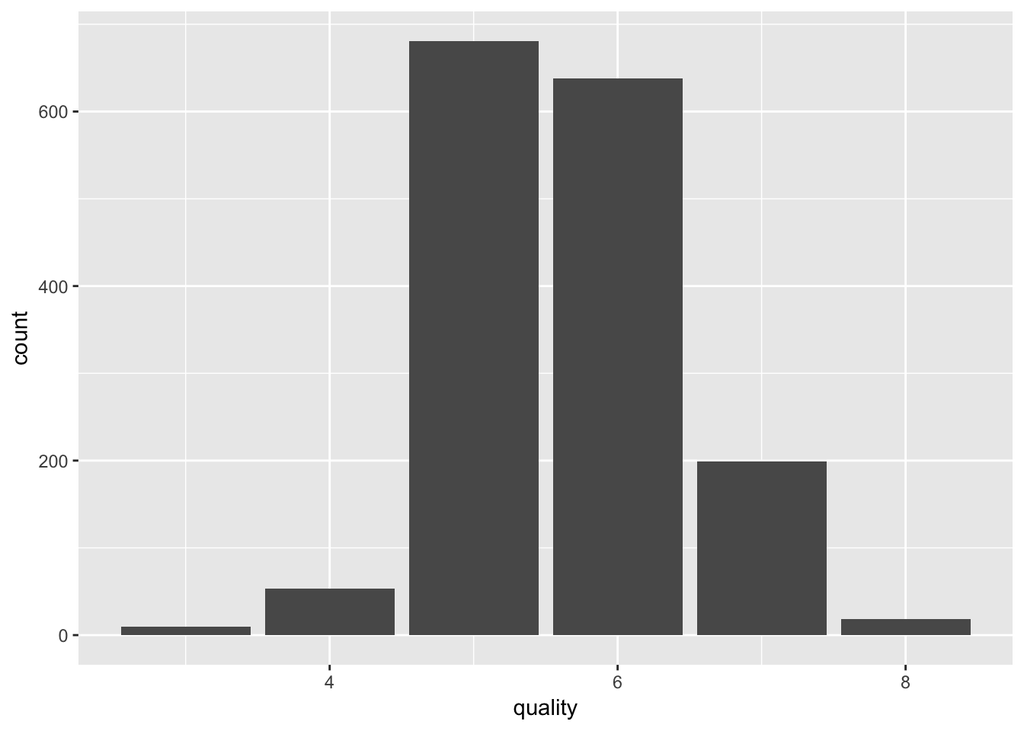

Wine qulities is skewed to the right with most qualities condense on level 5 and level 6.

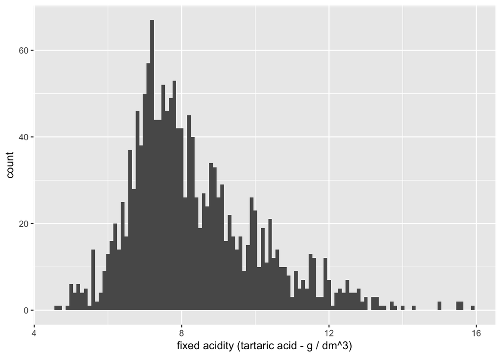

The level of non volatile acid in red wine is between 4.6 to 15.9g per liter wine. Most wines have it between 7 g/L to 9g/L.

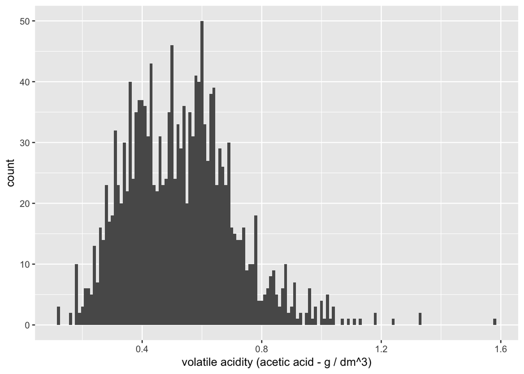

```
##    Min. 1st Qu.  Median    Mean 3rd Qu.    Max.
##  0.1200  0.3900  0.5200  0.5278  0.6400  1.5800
```

Volatile acidity represents the amount of acetic acid in wine which affects the sourness in wine taste. This varible seems to have a close relationship with wine quality.

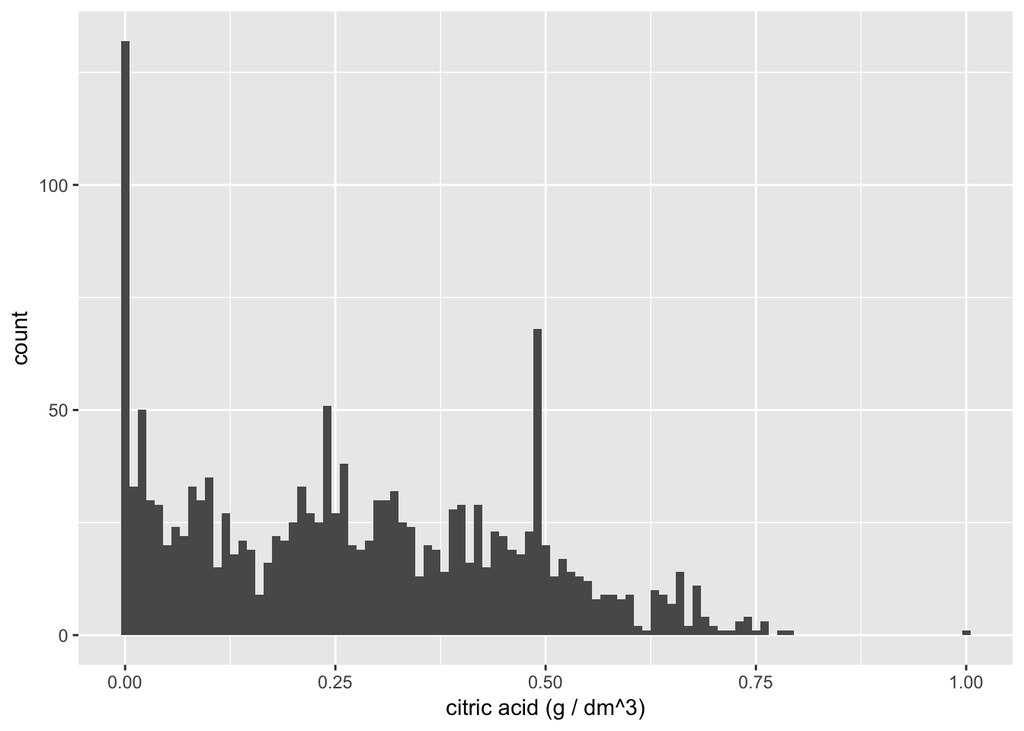

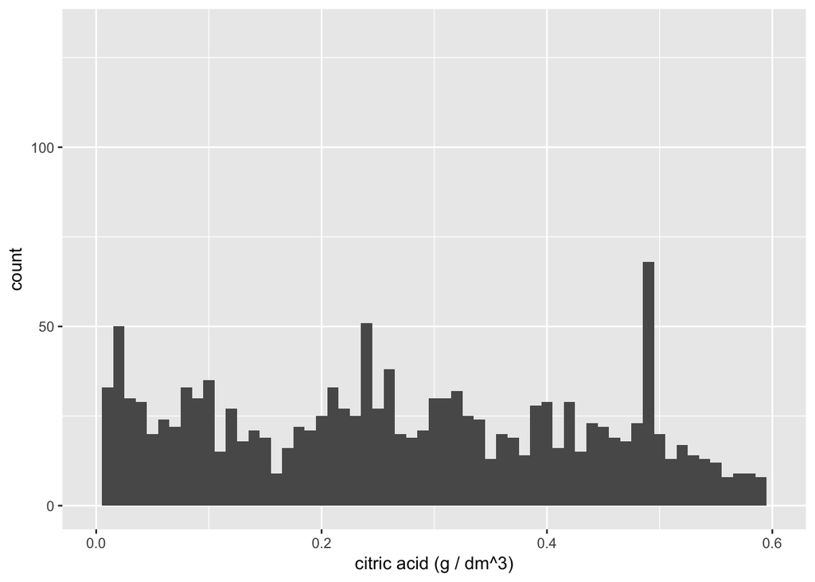

The amount of citric acid brings the freshness and taste in red wines. A number 130 wines contain none citric acid is questionable, I adjusted the confidence level of the data to clean out some outliers.

[figure not shown]

pH value describe the acidity in red wine from 0 (acidic) to 14 basic, most wines are between 3 and 4 on the scale.

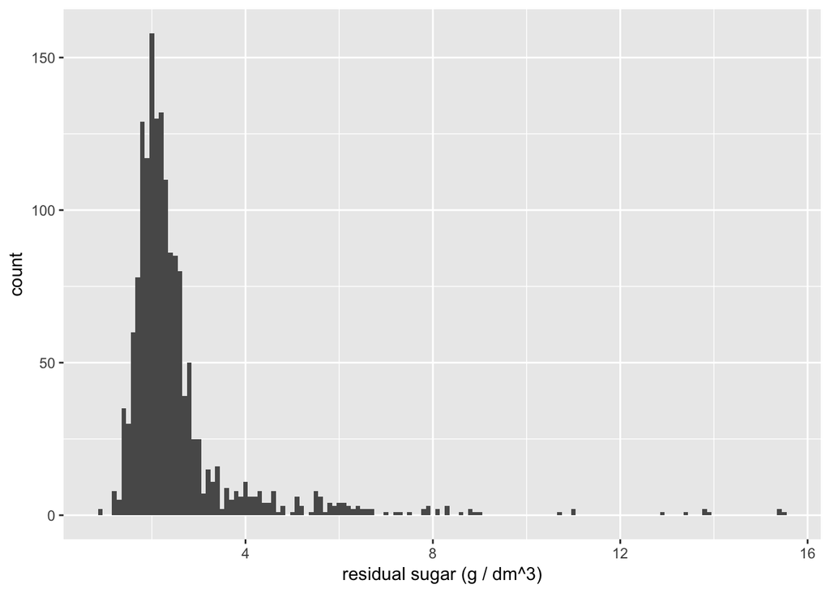

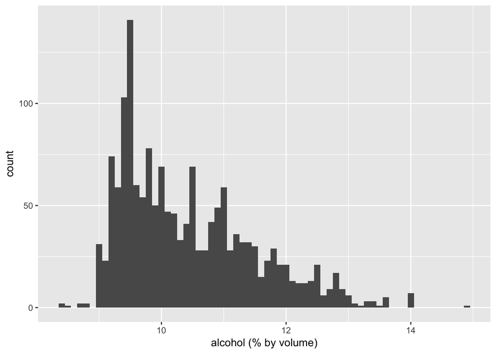

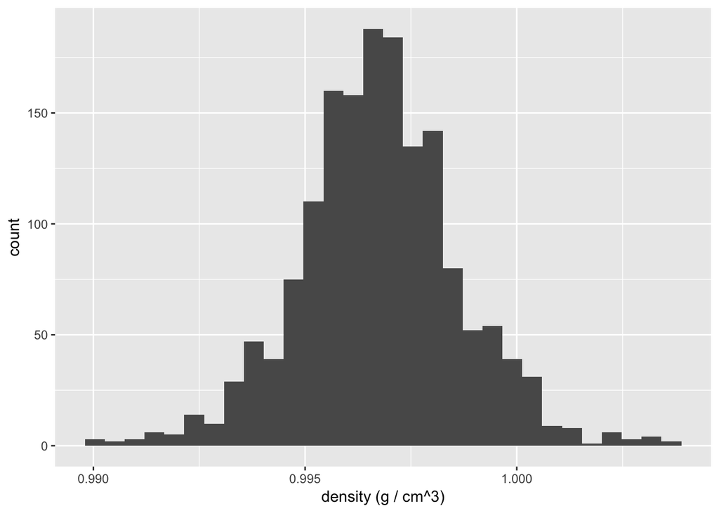

Wine body so called wine density is depending on the on the percent alcohol and sugar content.

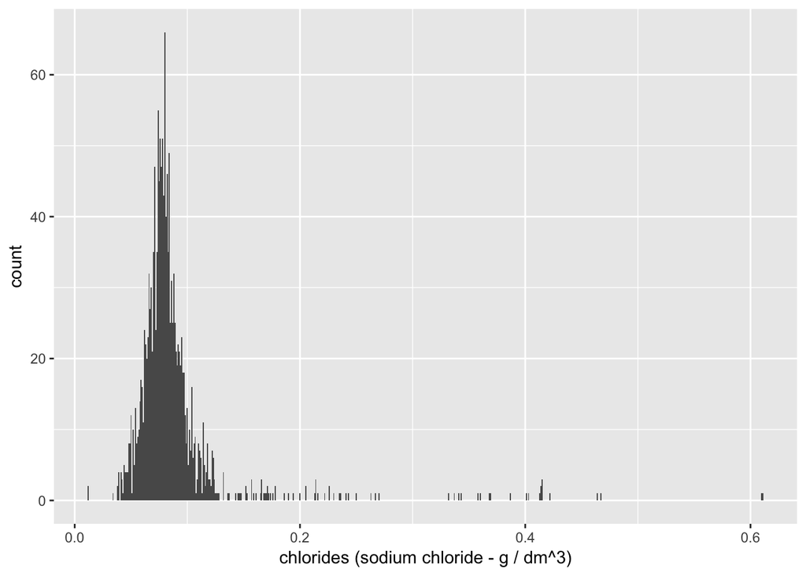

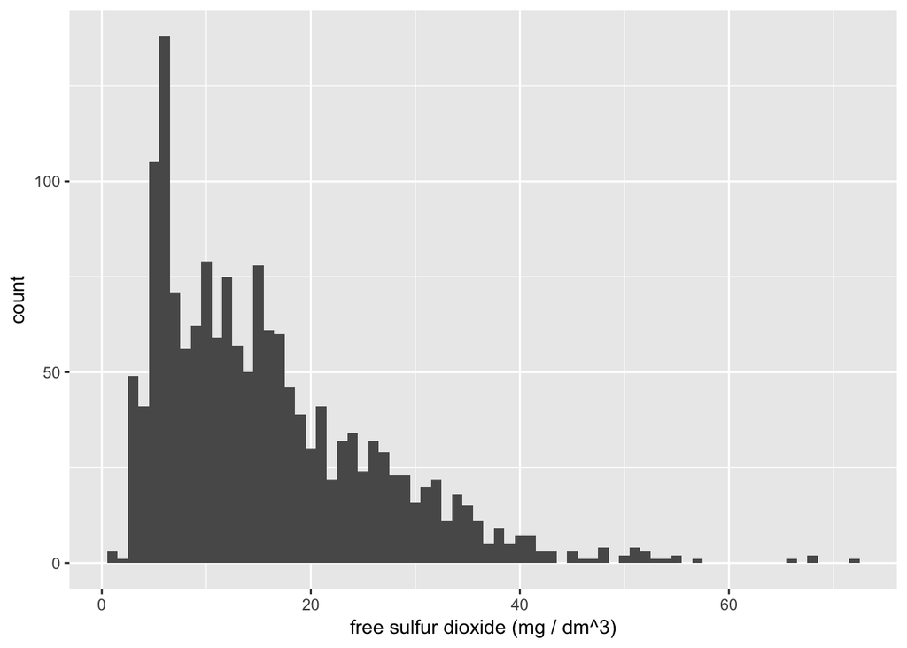

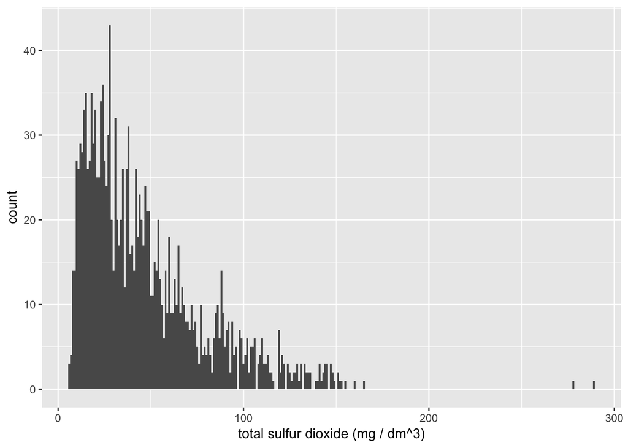

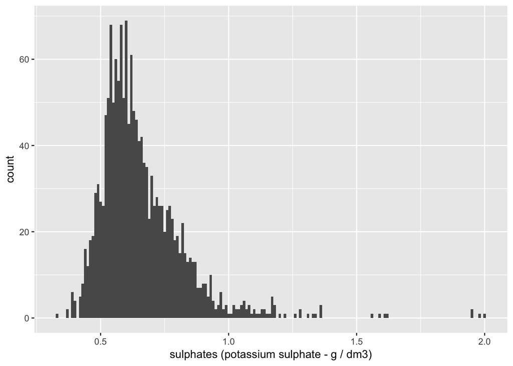

The antioxident composition inside wines, existing as in forms of sulfur dioxide if free concentration more than 50 ppm, human nose would sense it, as well as being tasted in the wine.

# Univariate Analysis

### What is the structure of your dataset?

There are 1599 red wines in the dataset with 12 features (fixed acidity, volatile acidity, citric acid, residual sugar, chlorides, free sulfur dioxide, total sulfur dioxide, density, pH, sulphates, alcohol and quality). The variable quality is output variable with scale from 1 to 10, which larger in level number, better in wine quality.

### What is/are the main feature(s) of interest in your dataset?

According to descirption, I can allege that volatile acidity plays a significant role in the quality. Meanwhile, density and sulfur elements are expected to influence the taste at a certain degree.

### What other features in the dataset do you think will help support your investigation into your feature(s) of interest?

Alcohol and pH values

### Did you create any new variables from existing variables in the dataset?

Yes, I created conditional means for volatile acidity and alcohol.

### Of the features you investigated, were there any unusual distributions? Did you perform any operations on the data to tidy, adjust, or change the form of the data? If so, why did you do this?

Nearly 130 wines contain none citric acid is questionable, I adjusted the confidence level of the data to clean out some outliers.

# Bivariate Plots Section

```
##                      fixed.acidity volatile.acidity citric.acid
## fixed.acidity                 1.00            -0.26        0.67
## volatile.acidity             -0.26             1.00       -0.55
## citric.acid                   0.67            -0.55        1.00
## residual.sugar                0.11             0.00        0.14
## chlorides                     0.09             0.06        0.20
## free.sulfur.dioxide          -0.15            -0.01       -0.06
## total.sulfur.dioxide         -0.11             0.08        0.04
## density                       0.67             0.02        0.36
## pH                           -0.68             0.23       -0.54
## sulphates                     0.18            -0.26        0.31
## alcohol                      -0.06            -0.20        0.11
## quality                       0.12            -0.39        0.23
##                      residual.sugar chlorides free.sulfur.dioxide
## fixed.acidity                  0.11      0.09               -0.15
## volatile.acidity               0.00      0.06               -0.01
## citric.acid                    0.14      0.20               -0.06
## residual.sugar                 1.00      0.06                0.19
## chlorides                      0.06      1.00                0.01
## free.sulfur.dioxide            0.19      0.01                1.00
## total.sulfur.dioxide           0.20      0.05                0.67
## density                        0.36      0.20               -0.02
## pH                            -0.09     -0.27                0.07
## sulphates                      0.01      0.37                0.05
## alcohol                        0.04     -0.22               -0.07
## quality                        0.01     -0.13               -0.05
##                      total.sulfur.dioxide density    pH sulphates alcohol
## fixed.acidity                       -0.11    0.67 -0.68      0.18   -0.06
## volatile.acidity                     0.08    0.02  0.23     -0.26   -0.20
## citric.acid                          0.04    0.36 -0.54      0.31    0.11
## residual.sugar                       0.20    0.36 -0.09      0.01    0.04
## chlorides                            0.05    0.20 -0.27      0.37   -0.22
## free.sulfur.dioxide                  0.67   -0.02  0.07      0.05   -0.07
## total.sulfur.dioxide                 1.00    0.07 -0.07      0.04   -0.21
## density                              0.07    1.00 -0.34      0.15   -0.50
## pH                                  -0.07   -0.34  1.00     -0.20    0.21
## sulphates                            0.04    0.15 -0.20      1.00    0.09
## alcohol                             -0.21   -0.50  0.21      0.09    1.00
## quality                             -0.19   -0.17 -0.06      0.25    0.48
##                      quality
## fixed.acidity           0.12
## volatile.acidity       -0.39
## citric.acid             0.23
## residual.sugar          0.01
## chlorides              -0.13
## free.sulfur.dioxide    -0.05
## total.sulfur.dioxide   -0.19
## density                -0.17
## pH                     -0.06
## sulphates               0.25
## alcohol                 0.48
## quality                 1.00
```

The quality of red wine tends to correlate with volatile acidity and alcohol content percentage. Respectively, volatile acidity and alcohol percentage correlates with citric acid and density. However, there is not a single variable strongly correlated to each other. One plausible reason is too few observations.

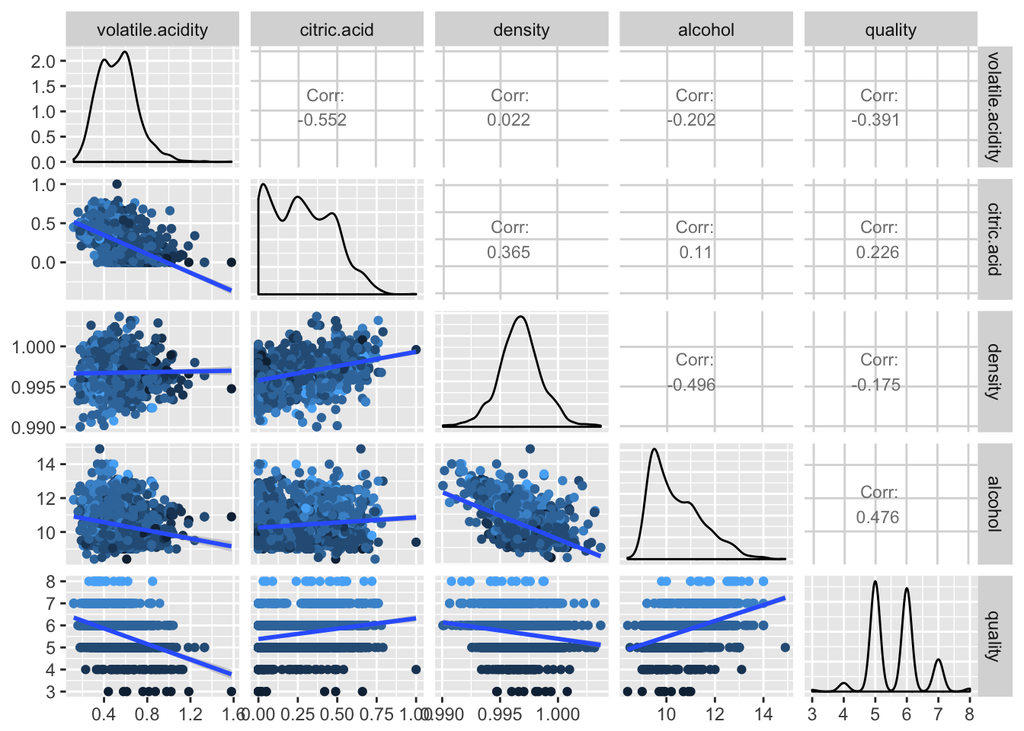

After visualizing all the relatively correlated variables, due to low correlation between the variables, wine quality is slightly positive proportional to alcohol, and decreases as volatile acid increases.

To better visualize the relationship between quality and other variables, I decide to group the dataset by quality, and take conditional mean of the varible for the plot.

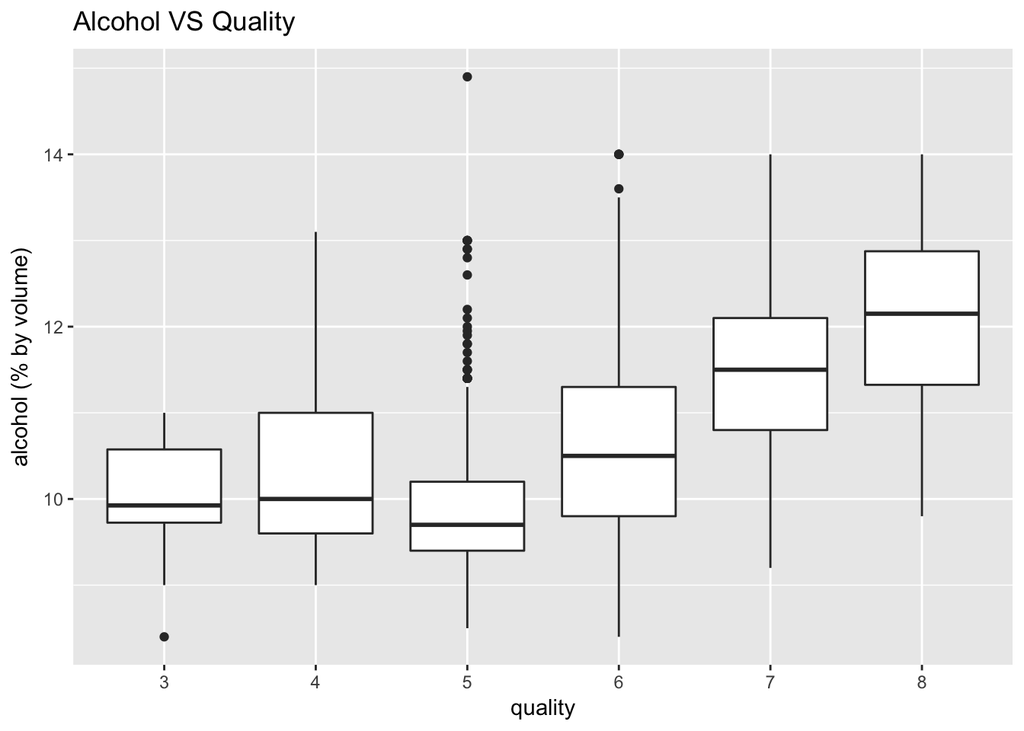

Once alcohol perentatge pasts approximately 10.5 pecent, the quality of wine tends to escalate linearly.

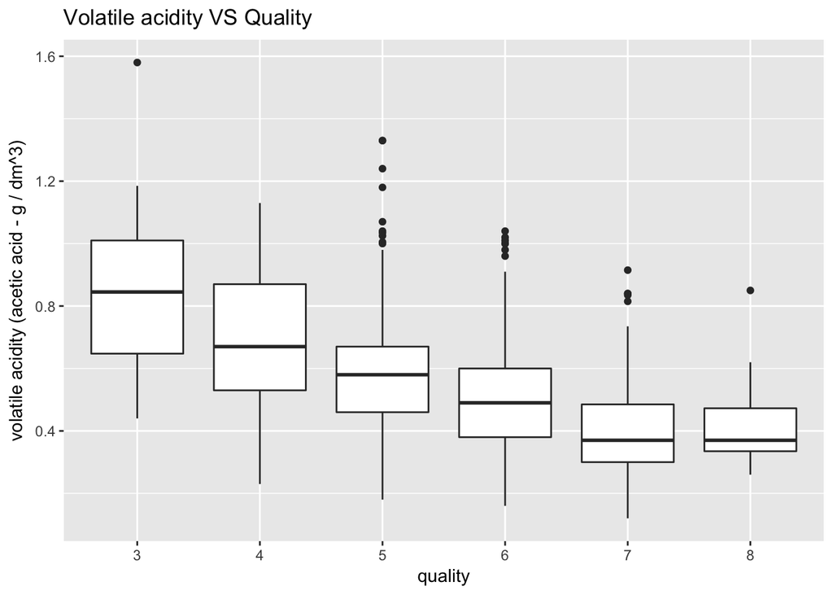

Sour tasting wines receive low grades.

# Bivariate Analysis

### Talk about some of the relationships you observed in this part of the investigation. How did the feature(s) of interest vary with other features in the dataset?

Quality is almost proportional to alcohol percent, but reciprocal to the amount of volatile acid.

### Did you observe any interesting relationships between the other features (not the main feature(s) of interest)?

Citric acid correlated negetively with volatile acid indeed surprised me. I was expecting that citric acid helps to keep evaporative acid in wine.

# Multivariate Plots Section

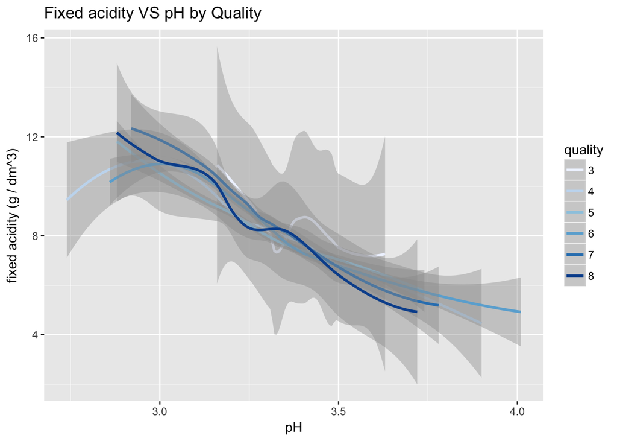

For better visulazing the relationship between fixed.acidity and pH respected to different qualities, I transformed the quality into ordered factor. As you can see, a deceasing in fixed acidity in better quality wine pH drop faster for pH greater than 3.5.

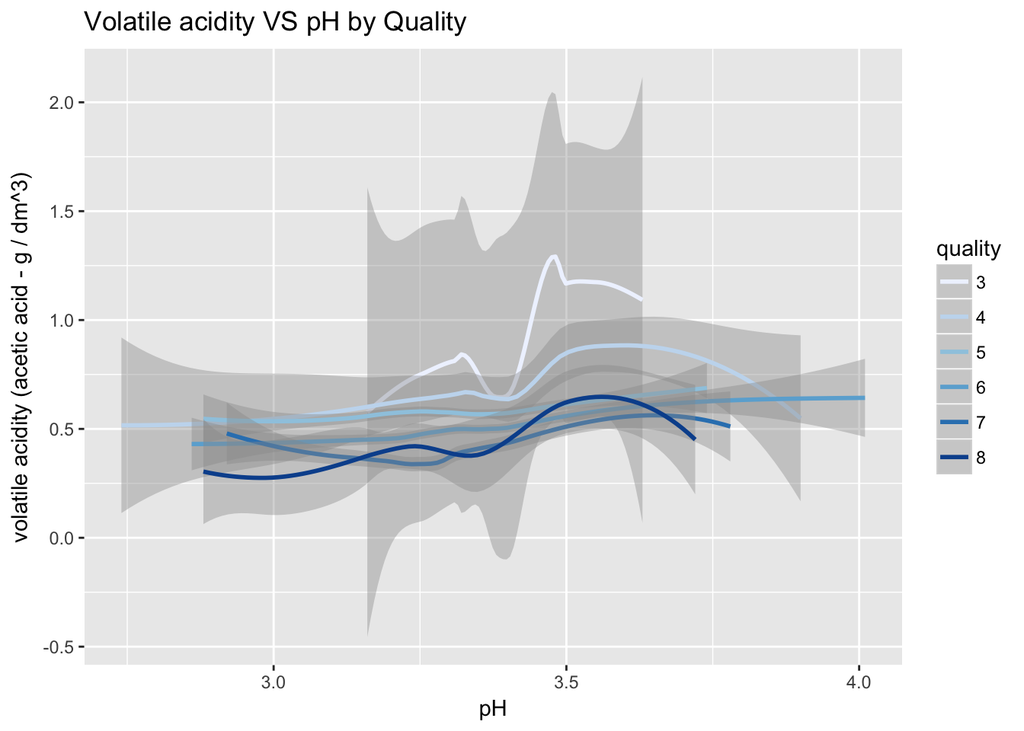

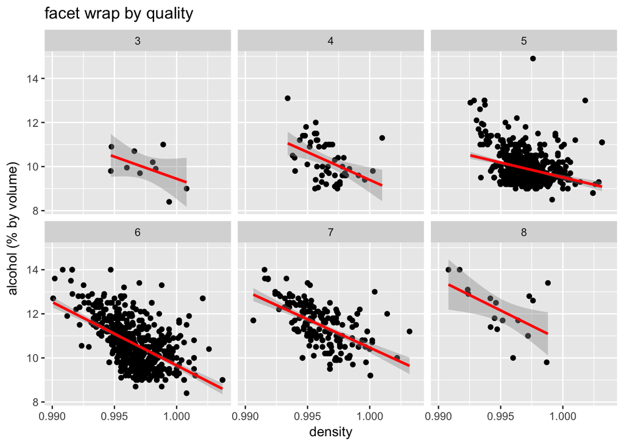

Alcohol reduces the density, on the contrary that residual sugar from fermentation make a heavy wine body. The balance between the sugar and the alcohol depends how wine makers control the process of fermentation and quality of the grapes.

```
##
## Calls:
## m1: lm(formula = I(quality) ~ I(volatile.acidity), data = redwines)
## m2: lm(formula = I(quality) ~ I(volatile.acidity) + alcohol, data = redwines)
## m3: lm(formula = I(quality) ~ I(volatile.acidity) + total.sulfur.dioxide,
##     data = redwines)
## m4: lm(formula = I(quality) ~ I(volatile.acidity) + sulphates, data = redwines)
## m5: lm(formula = I(quality) ~ I(volatile.acidity) + citric.acid,
##     data = redwines)
##
## ===============================================================================
##                            m1         m2         m3         m4         m5
## -------------------------------------------------------------------------------
##   (Intercept)           6.566***   3.095***   6.715***   5.963***   6.529***
##                        (0.058)    (0.184)    (0.061)    (0.105)    (0.089)
##   I(volatile.acidity)  -1.761***  -1.384***  -1.708***  -1.573***  -1.723***
##                        (0.104)    (0.095)    (0.103)    (0.106)    (0.125)
##   alcohol                          0.314***
##                                   (0.016)
##   total.sulfur.dioxide                       -0.004***
##                                              (0.001)
##   sulphates                                              0.764***
##                                                         (0.112)
##   citric.acid                                                       0.063
##                                                                    (0.115)
## -------------------------------------------------------------------------------
##   R-squared                 0.2        0.3        0.2        0.2        0.2
##   adj. R-squared            0.2        0.3        0.2        0.2        0.2
##   sigma                     0.7        0.7        0.7        0.7        0.7
##   F                       287.4      370.4      171.4      171.0      143.8
##   p                         0.0        0.0        0.0        0.0        0.0
##   Log-likelihood        -1794.3    -1621.8    -1771.1    -1771.4    -1794.2
##   Deviance                883.2      711.8      857.9      858.2      883.0
##   AIC                    3594.6     3251.6     3550.2     3550.7     3596.3
##   BIC                    3610.8     3273.1     3571.7     3572.2     3617.8
##   N                      1599       1599       1599       1599       1599
## ===============================================================================
```

The variables in this linear model can account for 20% or 30% at most of the variance in the quality of wines. Not a great model. # Multivariate Analysis

### Talk about some of the relationships you observed in this part of the investigation. Were there features that strengthened each other in terms of looking at your feature(s) of interest?

A deceasing in fixed acidity in better quality wine pH drop faster for pH greater than 3.5.

### Were there any interesting or surprising interactions between features?

Wine body is one of the major criteria of wine assessment, I discovered that alcohol reduces the density, on the contrary that residual sugar from fermentation makes wine heavy.

### OPTIONAL: Did you create any models with your dataset? Discuss the strengths and limitations of your model.

Yes, I have to admit this linear model should not be used as a prediction model for wine quality.The variables in this linear model can account for 20% or 30% at most of the variance in the quality of wines. Due to the low correlation between variables and output variable, we will not be able to build a strong linear regression model base on the data given. ——

# Final Plots and Summary

### Plot One

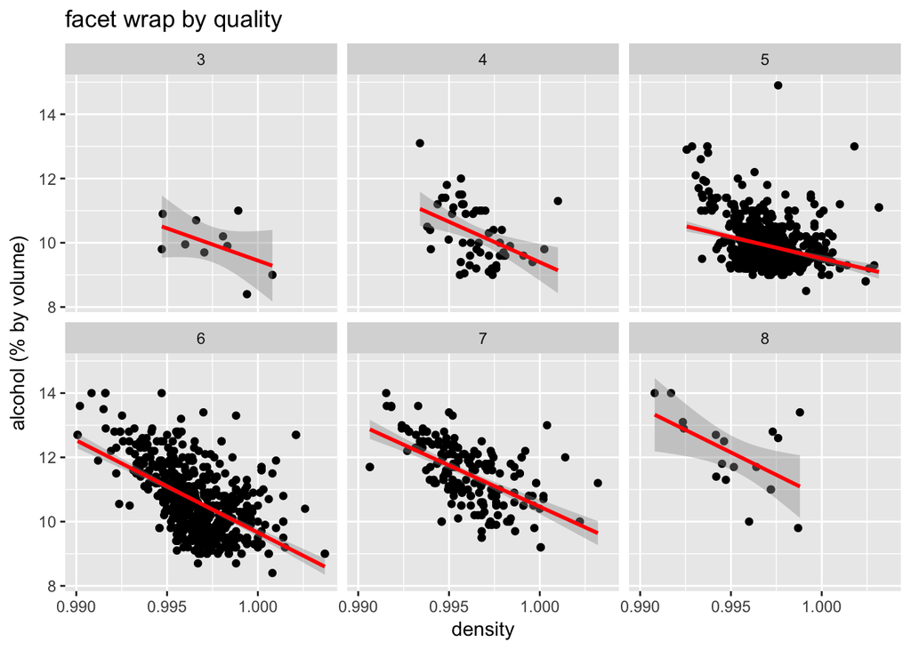

### Description One

One concept I need to introduce before we go further is wine body. It is an anlysis a way when the wine connoisseur decribes how wine feels in mouth after the taste.

Three categories: light(<12.5% alcohol), medium(12.5% to 13.5% alcohol) and full(>13.5% alcohol). The fact is that, nowadays, wine tasters prefer full body wines to light or medium wines. Presumably, depending on people’s taste, a better quality wine is heavier in body.

However, we have been told that body has been defined as the more alcohol wine contains, it becomes more viscous so that it becomes heavier.

This concept is not well supported by our analysis. We can see that the density increases when there is less alcohol. So, can people really tell how good a wine by their tongues?

### Plot Two

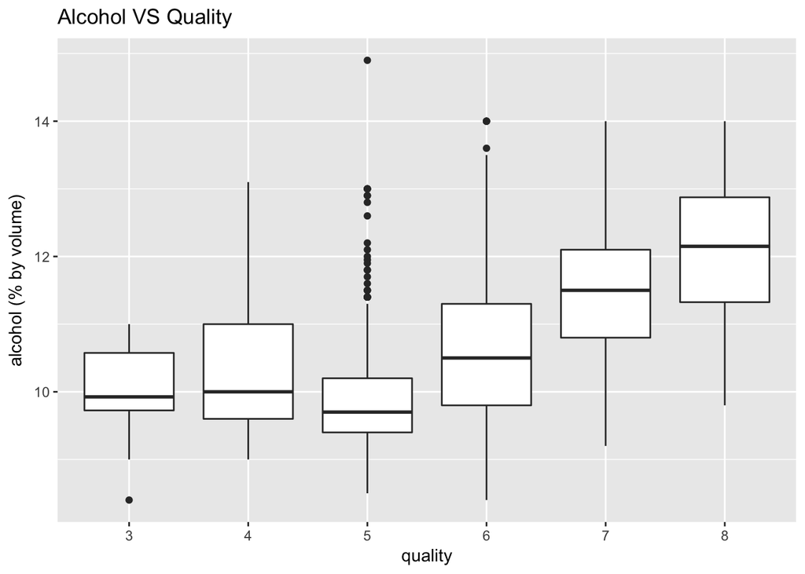

### Description Two

The concept has been proved wrong in the previous description. But the fact that people prefer full bodied wine seems to appear to be true in the graph above. We can deduce that somehow people does taste more flavor in wines with more alochol in it. Another theory saying that more alcohol would extract other elements and molicules in grapes might explain a little, or they just get pleased with more alcohol.

### Plot Three

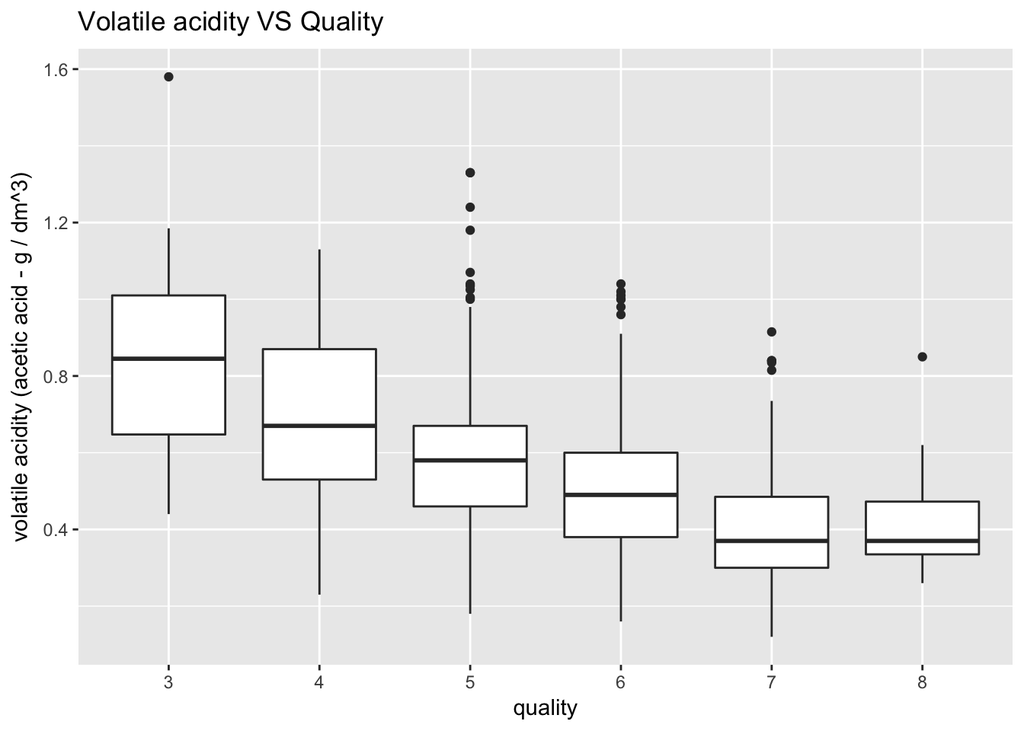

### Description Three

Another interesting discover here is that people does not like volatile acid. It stimilates our palate with sourness. You don’t want a vinegar taste wine.

# Reflection

The red wines data set contains information on 1599 wines across twelve variables from around 2009. I started by understanding the individual variables and exploring interesting questions by making observations on plots. I did make a linear model to predict the quality of wine, but it was not reliable.

limitations of this model include data source. Given that at least 3 wine experts rated the quality of each wine, providing a rating between 0 and 10 , results could be very bias since wine tasting is highly depending on experts’ personal judgements, not the universal standard.

For future analysis on red wines, a data set includes pubilc grading through blind testing is recommended. Compared to the wine experts judgement, a generalized data is relatively unbias. As a reference, we can figure out if public agrees that higher score wine graded by experts tastes better.